# Project 5

Si +

2022-10-07

# Introduction

Previous research has shown that activity does not cause a rise in body temperature due to various homeostatic regulatory processes. A literature review on human thermoregulation (Lim, Byrne, and Lee 2008) found that, despite heat production during exercise, thermoregulation mechanisms help maintain a core body temperature. This study will further explore the effects of physical activity on human body temperature.

# Methods

For the “couch” data, the participant sat on a couch for 5 minutes, then the temperature sensor was placed under in their axillary region (armpit) and data was collected for 100 seconds. This was repeated for each participant.

For the “active” data, the participant did jumping jacks for 5 minutes, then the temperature sensor was placed under in their axillary region (armpit) and data was collected for 100 seconds. This was repeated for each participant.

# Results

```r
library(tidyverse)
dat.f <- list.files(pattern = "couch|active.csv") #find the files

dat.l <- list() #make an empty list

for(i in dat.f){
  met.dat<- unlist(strsplit(i,"_")) #split of the filename string
  who <- met.dat[1] #store the first element
  activity <- gsub(".csv","",met.dat[2]) #store second element, dropping CSV with gsub()
  dat.l[[i]]<- read_csv(i)%>%
    mutate(who=who,activity=activity) #read, then store data with additional columns of metada in list as position unique to i

}
```

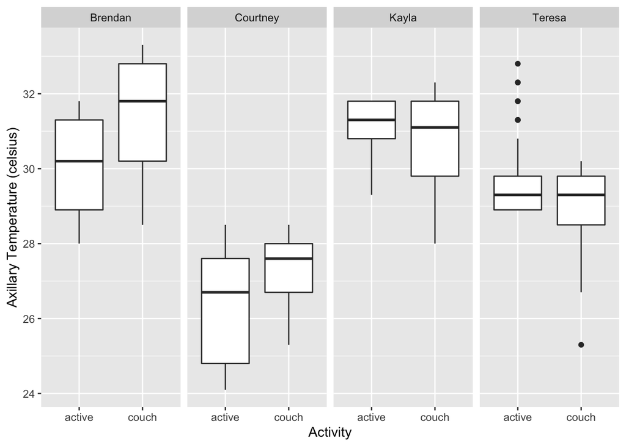

```r
dat <- do.call(rbind,dat.l) #combine the list into table

dat%>%
  ggplot()+geom_boxplot(aes(x=activity,y=degC))+facet_grid(.~who) + xlab("Activity") + ylab("Axillary Temperature (celsius)") #plot to see what we get
```

# Discussion

After analyzing our data and comparing it to the literature, our data is comparable with other findings. No participant showed a significant increase in body temperature after exercise (i.e., five minutes of jumping jacks) as compared to after rest (i.e., five minutes sitting). During exercise, thermoregulation processes augment proportionally to the increased heat production in order to prevent rising temperatures in tissues (Kenny and McGinn 2017). Specifically, metabolic heat production can increase by 10- to 20-fold during physical activity, but less than 30% of that generated heat is converted to mechanical energy. The remaining 70% of generated heat should be transported to the periphery of the body and dissipated to the environment via thermoregulation (Lim, Byrne, and Lee 2008). Some of these thermoregulatory processes include cutaneous vasodilation and sweating, which are induced by the autonomic nervous system, and evaporative heat loss (Kenny and McGinn 2017). These findings are important to the overall understanding of homeostasis and thermoregulation in humans and, in a broader sense, endotherms.

# Author Contributions

The Si-Plus team worked together to create Project Report 5. Brendan set up the wiring of the Arduino board and temperature sensor and ran the Arduino code during the experiments. Teresa and Kayla worked on the R code, the graphs, and the write-ups. Kayla and Courtney completed background research used to frame this experiment. Teresa created the bibliography.

Excellent work! 15/15

# References

Kenny, Glen P., and Ryan McGinn. 2017. “Restoration of Thermoregulation After Exercise.” *Journal of Applied Physiology* 122 (4): 933–44. https://doi.org/10.1152/japplphysiol.00517.2016.

Lim, Chin, Chris Byrne, and Jason Lee. 2008. “Human Thermoregulation and Measurement of Body Temperature in Exercise and Clinical Settings.” *Annals of the Academy of Medicine, Singapore* 37 (May): 347–53.